# Analisis Exploratorio de Hurtos en Colombia

Lina Marcela Quintero - Felipe Clement Santacruz

2019-04-26

# 1 Carga de Datos

## 1.1 Hurto 2017

```r
data_hurto_raw <- read.csv("hurto.csv")
str(data_hurto_raw)
```

```
## 'data.frame':    185105 obs. of  20 variables:
##  $ Fecha             : Factor w/ 365 levels "01/01/2017 12:00:00 AM",..: 1 1 1 1 1 1 1 1 1 1 ...
##  $ Departamento      : Factor w/ 32 levels "AMAZONAS","ANTIOQUIA",..: 2 2 2 2 2 2 2 2 2 2 ...
##  $ Municipio         : Factor w/ 901 levels "ABEJORRAL","ABREGO",..: 443 443 443 443 443 443 443 443 443 443 ...
##  $ Día               : Factor w/ 7 levels "Domingo","Jueves",..: 1 1 1 1 1 1 1 1 1 1 ...
##  $ Hora              : Factor w/ 1390 levels "12/31/1899 01:00:00 AM",..: 1040 1040 229 346 346 346 116 801 801 623 ...
##  $ Barrio            : Factor w/ 13990 levels "       VDA.  ANDALUCIA",..: 5586 5586 5586 5990 7073 10005 2224 5586 9170 8286 ...
##  $ Zona              : Factor w/ 3 levels "OTRAS","RURAL",..: 3 3 3 3 3 3 3 3 3 3 ...
##  $ Clase.de.sitio    : Factor w/ 384 levels "-","AEROPUERTO",..: 382 382 382 382 382 382 382 382 382 84 ...
##  $ Arma.empleada     : Factor w/ 16 levels "-","ALUCINOGENOS",..: 3 3 3 14 4 14 14 14 4 14 ...
##  $ Móvil.Agresor     : Factor w/ 15 levels "-","A PIE","BICICLETA",..: 2 2 2 6 12 2 2 2 14 2 ...
##  $ Móvil.Victima     : Factor w/ 15 levels "-","A PIE","BICICLETA",..: 2 2 2 13 13 2 2 2 5 2 ...
##  $ Edad              : int  39 43 26 29 37 87 30 59 35 28 ...
##  $ Sexo              : Factor w/ 3 levels "-","FEMENINO",..: 3 3 2 2 3 3 3 3 3 3 ...
##  $ Estado.civil      : Factor w/ 7 levels "-","CASADO","DIVORCIADO",..: 6 6 5 6 2 2 5 5 6 6 ...
##  $ País.de.nacimiento: Factor w/ 84 levels "-","AFGANISTAN",..: 20 20 20 20 20 20 20 20 20 20 ...
##  $ Clase.de.empleado : Factor w/ 36 levels "-","AFRODESCENDIENTE",..: 17 17 17 17 26 30 26 26 26 17 ...
##  $ Profesión         : Factor w/ 168 levels "-","ADMINISTRACION  AGROINDUSTRIAL",..: 1 1 1 1 1 1 1 1 1 1 ...
##  $ Escolaridad       : Factor w/ 8 levels "-","ANALFABETA",..: 5 4 5 5 5 5 5 5 5 5 ...
##  $ Código.DANE       : int  5001000 5001000 5001000 5001000 5001000 5001000 5001000 5001000 5001000 5001000 ...
##  $ Cantidad          : int  1 1 1 1 1 1 1 1 1 1 ...
```

## 1.2 Pobloacion por Municipio

```r
data_municipios_raw <- read.csv("municipios.csv")
str(data_municipios_raw)
```

```
## 'data.frame':    1123 obs. of  112 variables:
##  $ DP     : int  5 5 5 5 5 5 5 5 5 5 ...
##  $ DPNOM  : Factor w/ 34 levels "","Amazonas",..: 3 3 3 3 3 3 3 3 3 3 ...
##  $ DPMP   : int  5001 5002 5004 5021 5030 5031 5034 5036 5038 5040 ...
##  $ MPIO   : Factor w/ 1041 levels "Abejorral","Abrego",..: 519 1 3 20 30 31 36 37 38 40 ...
##  $ X1985  : Factor w/ 1015 levels "0","1,024","1,116",..: 12 471 516 649 401 272 606 767 122 108 ...
##  $ X1986  : Factor w/ 1023 levels "0","1,026","1,055",..: 13 474 521 658 417 283 616 776 139 119 ...
##  $ X1987  : Factor w/ 1018 levels "0","1,059","1,093",..: 13 467 530 661 419 288 622 780 143 117 ...
##  $ X1988  : Factor w/ 1028 levels "0","1,094","1,130",..: 15 469 529 670 428 297 628 789 152 124 ...
##  $ X1989  : Factor w/ 1028 levels "0","1,011","1,011,952",..: 16 470 538 678 440 302 627 791 155 126 ...
##  $ X1990  : Factor w/ 1026 levels "0","1,030,294",..: 17 465 536 671 443 303 621 790 153 125 ...
##  $ X1991  : Factor w/ 1035 levels "0","1,039","1,046,745",..: 19 465 537 675 450 309 634 807 158 130 ...
##  $ X1992  : Factor w/ 1033 levels "0","1,032","1,060,949",..: 17 452 532 669 454 313 632 812 158 131 ...
##  $ X1993  : Factor w/ 1048 levels "0","1,070","1,072,677",..: 20 457 543 679 469 327 644 825 165 143 ...
##  $ X1994  : Factor w/ 1049 levels "0","1,081,892",..: 20 455 543 681 476 333 648 834 168 150 ...
```

[output cut: 86 more lines]

## 1.3 Estadisticas Educación por ETC

```r
data_educacion_raw <- read.csv("educacion.csv")
str(data_educacion_raw)
```

```
## 'data.frame':    661 obs. of  37 variables:
##  $ AÑO                        : int  2012 2013 2011 2014 2017 2015 2016 2014 2011 2013 ...
##  $ CÓDIGO_ETC                 : int  3828 3828 3828 3828 3828 3828 3828 3758 3758 3758 ...
##  $ ETC                        : Factor w/ 95 levels "Amazonas (ETC)",..: 1 1 1 1 1 1 1 2 2 2 ...
##  $ POBLACIÓN_5_16             : int  22194 22123 22223 22167 22269 22212 22243 586947 599438 590211 ...
##  $ TASA_MATRICULACIÓN_5_16    : num  8.19e+14 8.18e+01 8.23e+01 8.21e+01 8.36e+01 ...
##  $ COBERTURA_NETA             : num  81.9 81.8 82.3 82.1 82.1 ...
##  $ COBERTURA_NETA_TRANSICIÓN  : num  60.2 48.4 63.7 43.9 49 ...
##  $ COBERTURA_NETA_PRIMARIA    : num  85.6 84 87.2 84.9 80.6 ...
##  $ COBERTURA_NETA_SECUNDARIA  : num  53.3 58.2 50.6 57.7 60.7 ...
##  $ COBERTURA_NETA_MEDIA       : num  22.3 22.1 21.9 23.1 30.1 ...
##  $ COBERTURA_BRUTA            : num  94.8 95.4 94.5 95.7 96.6 ...
##  $ COBERTURA_BRUTA_TRANSICIÓN : num  60.2 96.9 94.5 89.5 92.6 ...
##  $ COBERTURA_BRUTA_PRIMARIA   : num  85.6 111.8 117.8 114 108 ...
##  $ COBERTURA_BRUTA_SECUNDARIA : num  53.3 91.2 82.5 89.1 94.3 ...
```

[output cut: 23 more lines]

# 2 Limpieza

## 2.1 Hurto 2017

Se eliminan las columnas:

```r
removable_columns <- c("Fecha", "Hora", "Barrio", "País.de.nacimiento", "Profesión", "Código.DANE", "Cantidad")

data_hurto_tidy <- data_hurto_raw[, -which(colnames(data_hurto_raw) %in% removable_columns)]

str(data_hurto_tidy)
```

```
## 'data.frame':    185105 obs. of  13 variables:
##  $ Departamento     : Factor w/ 32 levels "AMAZONAS","ANTIOQUIA",..: 2 2 2 2 2 2 2 2 2 2 ...
##  $ Municipio        : Factor w/ 901 levels "ABEJORRAL","ABREGO",..: 443 443 443 443 443 443 443 443 443 443 ...
##  $ Día              : Factor w/ 7 levels "Domingo","Jueves",..: 1 1 1 1 1 1 1 1 1 1 ...
##  $ Zona             : Factor w/ 3 levels "OTRAS","RURAL",..: 3 3 3 3 3 3 3 3 3 3 ...
##  $ Clase.de.sitio   : Factor w/ 384 levels "-","AEROPUERTO",..: 382 382 382 382 382 382 382 382 382 84 ...
##  $ Arma.empleada    : Factor w/ 16 levels "-","ALUCINOGENOS",..: 3 3 3 14 4 14 14 14 4 14 ...
##  $ Móvil.Agresor    : Factor w/ 15 levels "-","A PIE","BICICLETA",..: 2 2 2 6 12 2 2 2 14 2 ...
##  $ Móvil.Victima    : Factor w/ 15 levels "-","A PIE","BICICLETA",..: 2 2 2 13 13 2 2 2 5 2 ...
##  $ Edad             : int  39 43 26 29 37 87 30 59 35 28 ...
##  $ Sexo             : Factor w/ 3 levels "-","FEMENINO",..: 3 3 2 2 3 3 3 3 3 3 ...
##  $ Estado.civil     : Factor w/ 7 levels "-","CASADO","DIVORCIADO",..: 6 6 5 6 2 2 5 5 6 6 ...
##  $ Clase.de.empleado: Factor w/ 36 levels "-","AFRODESCENDIENTE",..: 17 17 17 17 26 30 26 26 26 17 ...
##  $ Escolaridad      : Factor w/ 8 levels "-","ANALFABETA",..: 5 4 5 5 5 5 5 5 5 5 ...
```

Normalizamos los nombres de las columnas.

```r
colnames(data_hurto_tidy) <- c("departamento", "municipio", "dia", "zona", "clase_de_sitio", "arma_empleada", "movil_agresor", "movil_victima", "edad", "sexo", "estado_civil", "clase_de_empleado", "escolaridad")

str(data_hurto_tidy)
```

```
## 'data.frame':    185105 obs. of  13 variables:
##  $ departamento     : Factor w/ 32 levels "AMAZONAS","ANTIOQUIA",..: 2 2 2 2 2 2 2 2 2 2 ...
##  $ municipio        : Factor w/ 901 levels "ABEJORRAL","ABREGO",..: 443 443 443 443 443 443 443 443 443 443 ...
##  $ dia              : Factor w/ 7 levels "Domingo","Jueves",..: 1 1 1 1 1 1 1 1 1 1 ...
##  $ zona             : Factor w/ 3 levels "OTRAS","RURAL",..: 3 3 3 3 3 3 3 3 3 3 ...
##  $ clase_de_sitio   : Factor w/ 384 levels "-","AEROPUERTO",..: 382 382 382 382 382 382 382 382 382 84 ...
##  $ arma_empleada    : Factor w/ 16 levels "-","ALUCINOGENOS",..: 3 3 3 14 4 14 14 14 4 14 ...
##  $ movil_agresor    : Factor w/ 15 levels "-","A PIE","BICICLETA",..: 2 2 2 6 12 2 2 2 14 2 ...
##  $ movil_victima    : Factor w/ 15 levels "-","A PIE","BICICLETA",..: 2 2 2 13 13 2 2 2 5 2 ...
##  $ edad             : int  39 43 26 29 37 87 30 59 35 28 ...
##  $ sexo             : Factor w/ 3 levels "-","FEMENINO",..: 3 3 2 2 3 3 3 3 3 3 ...
##  $ estado_civil     : Factor w/ 7 levels "-","CASADO","DIVORCIADO",..: 6 6 5 6 2 2 5 5 6 6 ...
##  $ clase_de_empleado: Factor w/ 36 levels "-","AFRODESCENDIENTE",..: 17 17 17 17 26 30 26 26 26 17 ...
##  $ escolaridad      : Factor w/ 8 levels "-","ANALFABETA",..: 5 4 5 5 5 5 5 5 5 5 ...
```

Se elimina `(CT)` de los datos en la columna `Municipio`.

```r
remove_capital <- function(city_factor) {
  city <- as.character(city_factor)
  no_capital <- gsub(" \\(CT\\)", "", city)

  return(no_capital)
}

data_hurto_tidy$municipio <- as.factor(sapply(data_hurto_tidy$municipio, remove_capital))
str(data_hurto_tidy)
```

```
## 'data.frame':    185105 obs. of  13 variables:
##  $ departamento     : Factor w/ 32 levels "AMAZONAS","ANTIOQUIA",..: 2 2 2 2 2 2 2 2 2 2 ...
##  $ municipio        : Factor w/ 899 levels "ABEJORRAL","ABREGO",..: 442 442 442 442 442 442 442 442 442 442 ...
##  $ dia              : Factor w/ 7 levels "Domingo","Jueves",..: 1 1 1 1 1 1 1 1 1 1 ...
##  $ zona             : Factor w/ 3 levels "OTRAS","RURAL",..: 3 3 3 3 3 3 3 3 3 3 ...
##  $ clase_de_sitio   : Factor w/ 384 levels "-","AEROPUERTO",..: 382 382 382 382 382 382 382 382 382 84 ...
##  $ arma_empleada    : Factor w/ 16 levels "-","ALUCINOGENOS",..: 3 3 3 14 4 14 14 14 4 14 ...
##  $ movil_agresor    : Factor w/ 15 levels "-","A PIE","BICICLETA",..: 2 2 2 6 12 2 2 2 14 2 ...
##  $ movil_victima    : Factor w/ 15 levels "-","A PIE","BICICLETA",..: 2 2 2 13 13 2 2 2 5 2 ...
##  $ edad             : int  39 43 26 29 37 87 30 59 35 28 ...
##  $ sexo             : Factor w/ 3 levels "-","FEMENINO",..: 3 3 2 2 3 3 3 3 3 3 ...
##  $ estado_civil     : Factor w/ 7 levels "-","CASADO","DIVORCIADO",..: 6 6 5 6 2 2 5 5 6 6 ...
##  $ clase_de_empleado: Factor w/ 36 levels "-","AFRODESCENDIENTE",..: 17 17 17 17 26 30 26 26 26 17 ...
##  $ escolaridad      : Factor w/ 8 levels "-","ANALFABETA",..: 5 4 5 5 5 5 5 5 5 5 ...
```

Se cambian todos los `-` por `NA` y se eliminan las observaciones con por lo menos un `NA`.

```r
which(names(summary(data_hurto_tidy$clase_de_sitio)) == "-")
```

```
## integer(0)
```

```r
data_hurto <- data_hurto_tidy
data_hurto[data_hurto_tidy == "-"] <- NA
data_hurto <- data_hurto[complete.cases(data_hurto), ]

str(data_hurto)
```

```
## 'data.frame':    182418 obs. of  13 variables:
##  $ departamento     : Factor w/ 32 levels "AMAZONAS","ANTIOQUIA",..: 2 2 2 2 2 2 2 2 2 2 ...
##  $ municipio        : Factor w/ 899 levels "ABEJORRAL","ABREGO",..: 442 442 442 442 442 442 442 442 442 442 ...
##  $ dia              : Factor w/ 7 levels "Domingo","Jueves",..: 1 1 1 1 1 1 1 1 1 1 ...
##  $ zona             : Factor w/ 3 levels "OTRAS","RURAL",..: 3 3 3 3 3 3 3 3 3 3 ...
##  $ clase_de_sitio   : Factor w/ 384 levels "-","AEROPUERTO",..: 382 382 382 382 382 382 382 382 382 84 ...
##  $ arma_empleada    : Factor w/ 16 levels "-","ALUCINOGENOS",..: 3 3 3 14 4 14 14 14 4 14 ...
##  $ movil_agresor    : Factor w/ 15 levels "-","A PIE","BICICLETA",..: 2 2 2 6 12 2 2 2 14 2 ...
##  $ movil_victima    : Factor w/ 15 levels "-","A PIE","BICICLETA",..: 2 2 2 13 13 2 2 2 5 2 ...
##  $ edad             : int  39 43 26 29 37 87 30 59 35 28 ...
##  $ sexo             : Factor w/ 3 levels "-","FEMENINO",..: 3 3 2 2 3 3 3 3 3 3 ...
##  $ estado_civil     : Factor w/ 7 levels "-","CASADO","DIVORCIADO",..: 6 6 5 6 2 2 5 5 6 6 ...
##  $ clase_de_empleado: Factor w/ 36 levels "-","AFRODESCENDIENTE",..: 17 17 17 17 26 30 26 26 26 17 ...
##  $ escolaridad      : Factor w/ 8 levels "-","ANALFABETA",..: 5 4 5 5 5 5 5 5 5 5 ...
```

Se cambia el orden de unos factores

```r
data_hurto$escolaridad <- factor(data_hurto$escolaridad, levels = c("NO REPORTADO", "ANALFABETA", "PRIMARIA", "SECUNDARIA", "TECNOLOGO", "TECNICO", "SUPERIOR"))

data_hurto$dia <- factor(data_hurto$dia, levels = c("Domingo", "Lunes", "Martes", "Miércoles", "Jueves", "Viernes", "Sábado"))
```

## 2.2 Poblacion por municipio

Dejamos:

- MPIO que es el nombre del municipio
- X2017 que es la poblacion por municipio en 2017

```r
target_columns <- c("MPIO", "X2017")
data_municipios_tidy <- data_municipios_raw[, which(colnames(data_municipios_raw) %in% target_columns)]

str(data_municipios_tidy)
```

```
## 'data.frame':    1123 obs. of  2 variables:
##  $ MPIO : Factor w/ 1041 levels "Abejorral","Abrego",..: 519 1 3 20 30 31 36 37 38 40 ...
##  $ X2017: Factor w/ 1100 levels "1,024,882","1,066",..: 378 327 349 561 542 443 762 1057 79 289 ...
```

Normalizamos el nombre de cada columna

```r
colnames(data_municipios_tidy) <- c("municipio", "poblacion_2017")
str(data_municipios_tidy)
```

```
## 'data.frame':    1123 obs. of  2 variables:
##  $ municipio     : Factor w/ 1041 levels "Abejorral","Abrego",..: 519 1 3 20 30 31 36 37 38 40 ...
##  $ poblacion_2017: Factor w/ 1100 levels "1,024,882","1,066",..: 378 327 349 561 542 443 762 1057 79 289 ...
```

Convertimos la columna poblacion_2017 en numerica

```r
factor_to_int <- function(a_factor) {
  a_char <- as.character(a_factor)
  no_commas <- gsub(",", "", a_char)
  num <- as.integer(no_commas)

  return(num)
}

data_municipios_tidy$poblacion_2017 <- sapply(data_municipios_tidy$poblacion_2017, factor_to_int)
data_municipios_tidy$municipio <- sapply(data_municipios_tidy$municipio, toupper)

str(data_municipios_tidy)
```

```
## 'data.frame':    1123 obs. of  2 variables:
##  $ municipio     : chr  "MEDELLÍN" "ABEJORRAL" "ABRIAQUÍ" "ALEJANDRÍA" ...
##  $ poblacion_2017: int  2508452 19096 2019 3393 29980 22414 46621 9216 11139 17521 ...
```

Eliminamos la fila que tiene el total nacional

```r
data_municipios_tidy <- data_municipios_tidy[data_municipios_tidy$municipio != "TOTAL NACIONAL", ]

str(data_municipios_tidy)
```

```
## 'data.frame':    1122 obs. of  2 variables:
##  $ municipio     : chr  "MEDELLÍN" "ABEJORRAL" "ABRIAQUÍ" "ALEJANDRÍA" ...
##  $ poblacion_2017: int  2508452 19096 2019 3393 29980 22414 46621 9216 11139 17521 ...
```

Eliminar la coma de `BOGOTA, D.C`

```r
bogota_row <- data_municipios_tidy[data_municipios_tidy$municipio == "BOGOTÁ, D.C.", ]
bogota_row$municipio <- c("BOGOTÁ D.C.")

data_municipios_tidy[data_municipios_tidy$municipio == "BOGOTÁ, D.C.", ] <- bogota_row

data_municipios <- data_municipios_tidy
```

## 2.3 Educacion

Eliminamos la columna `CÓDIGO_ETC`

```r
data_educacion_tidy <- data_educacion_raw

data_educacion_tidy <- data_educacion_tidy[, -which(colnames(data_educacion_tidy) == "CÓDIGO_ETC")]
str(data_educacion_tidy)
```

```
## 'data.frame':    661 obs. of  36 variables:
##  $ AÑO                        : int  2012 2013 2011 2014 2017 2015 2016 2014 2011 2013 ...
##  $ ETC                        : Factor w/ 95 levels "Amazonas (ETC)",..: 1 1 1 1 1 1 1 2 2 2 ...
##  $ POBLACIÓN_5_16             : int  22194 22123 22223 22167 22269 22212 22243 586947 599438 590211 ...
##  $ TASA_MATRICULACIÓN_5_16    : num  8.19e+14 8.18e+01 8.23e+01 8.21e+01 8.36e+01 ...
##  $ COBERTURA_NETA             : num  81.9 81.8 82.3 82.1 82.1 ...
##  $ COBERTURA_NETA_TRANSICIÓN  : num  60.2 48.4 63.7 43.9 49 ...
##  $ COBERTURA_NETA_PRIMARIA    : num  85.6 84 87.2 84.9 80.6 ...
##  $ COBERTURA_NETA_SECUNDARIA  : num  53.3 58.2 50.6 57.7 60.7 ...
##  $ COBERTURA_NETA_MEDIA       : num  22.3 22.1 21.9 23.1 30.1 ...
##  $ COBERTURA_BRUTA            : num  94.8 95.4 94.5 95.7 96.6 ...
##  $ COBERTURA_BRUTA_TRANSICIÓN : num  60.2 96.9 94.5 89.5 92.6 ...
##  $ COBERTURA_BRUTA_PRIMARIA   : num  85.6 111.8 117.8 114 108 ...
##  $ COBERTURA_BRUTA_SECUNDARIA : num  53.3 91.2 82.5 89.1 94.3 ...
##  $ COBERTURA_BRUTA_MEDIA      : num  22.3 59.6 58 63.3 72.2 ...
```

[output cut: 22 more lines]

Normalizamos los nombres de las columnas

```r
colnames(data_educacion_tidy) <- sapply(colnames(data_educacion_tidy), tolower)
```

Conservamos solo el año 2017 y posteriormente eliminamos la columna

```r
data_educacion_tidy <- data_educacion_tidy[data_educacion_tidy$año == 2017, ]
data_educacion_tidy <- data_educacion_tidy[, -which(colnames(data_educacion_tidy) == "año")]

str(data_educacion_tidy)
```

```
## 'data.frame':    95 obs. of  35 variables:
##  $ etc                        : Factor w/ 95 levels "Amazonas (ETC)",..: 1 2 3 4 5 6 7 8 9 10 ...
##  $ población_5_16             : int  22269 588225 49431 75197 15106 54421 112847 37581 237521 93422 ...
##  $ tasa_matriculación_5_16    : num  83.6 82.4 59 75 67.8 ...
##  $ cobertura_neta             : num  82.1 82.3 59 75 67.6 ...
##  $ cobertura_neta_transición  : num  49 51.2 33 47.3 51.2 ...
##  $ cobertura_neta_primaria    : num  80.6 79.7 55.6 74 67.8 ...
##  $ cobertura_neta_secundaria  : num  60.7 68.3 52.2 58.4 59.7 ...
##  $ cobertura_neta_media       : num  30.1 36.7 26.6 30.9 37.8 ...
##  $ cobertura_bruta            : num  96.6 93.4 71.1 86.6 72.4 ...
##  $ cobertura_bruta_transición : num  92.6 71.9 51.3 83.2 67.1 ...
##  $ cobertura_bruta_primaria   : num  108 102 72.4 97 77.7 ...
##  $ cobertura_bruta_secundaria : num  94.3 99.7 82.9 85.6 75.6 ...
##  $ cobertura_bruta_media      : num  72.2 69.5 55.3 62.2 55.6 ...
##  $ tamaño_promedio_de_grupo   : num  21 29.5 35.8 21.8 27.4 ...
```

[output cut: 21 more lines]

Transformamos las ETC en mayuscula y removemos el (ETC)

```r
remove_etc <- function(city_factor) {
  city <- as.character(city_factor)
  no_capital <- gsub(" \\(ETC\\)", "", city)

  return(no_capital)
}

data_educacion_tidy$etc <- sapply(data_educacion_tidy$etc, toupper)
data_educacion_tidy$etc <- sapply(data_educacion_tidy$etc, remove_etc)
data_educacion_tidy$etc <- sapply(data_educacion_tidy$etc, remove_capital)

data_educacion <- data_educacion_tidy
```

# 3 Pre-procesamiento

Calculamos indice por municipio…

```r
hurtos_per_muni <- data_hurto %>%
  group_by(municipio) %>%
  summarize(
    cantidad_hurtos = n()
  )

muni_joined <- data_municipios %>%
  left_join(hurtos_per_muni, by = c("municipio" = "municipio"), copy = TRUE)
attach(muni_joined)
muni_joined$indice_hurtos <- (cantidad_hurtos / poblacion_2017) * 1000
detach(muni_joined)

muni_joined_sorted <- muni_joined[order(-muni_joined$poblacion_2017), ]

sum(is.na(muni_joined$cantidad_hurtos))
```

```
## [1] 155
```

```r
muni_top <- head(muni_joined_sorted, 30)
muni_top_sorted <- muni_top[order(-muni_top$indice_hurtos), ]
muni_top_sorted
```

```
##                 municipio poblacion_2017 cantidad_hurtos indice_hurtos
## 716                 PASTO         450645            4460     9.8969255
## 362               POPAYÁN         282453            2342     8.2916450
## 149           BOGOTÁ D.C.        8080734           64188     7.9433378
## 846           BUCARAMANGA         528497            4068     7.6973001
## 1                MEDELLÍN        2508452           17522     6.9851845
## 687         VILLAVICENCIO         506012            3514     6.9444993
## 605                 NEIVA         345806            2296     6.6395609
## 1006                 CALI        2420114           14681     6.0662432
## 832               PEREIRA         474335            2701     5.6942878
## 959                IBAGUÉ         564076            3010     5.3361604
## 820               ARMENIA         299712            1518     5.0648623
## 47               ENVIGADO         232903            1177     5.0536060
## 319             MANIZALES         398830            1883     4.7213098
## 933             SINCELEJO         282868            1327     4.6912341
```

[output cut: 16 more lines]

# 4 Analisis Lina

## 4.1 Analisis univariado dataset hurto

Aquí se tiene el analisis univariado para las siguientes variables: *Departamento* Zona *Clase.sitio* arma empleada *movil victima* sexo

A continuación empezamos a analizar cada una de las variables listadas. Vamos a observar como esta la distribución de estos datos

```r
columns_f_l <- c("municipio","departamento", "zona", "dia", "clase_de_sitio", "arma_empleada", "movil_victima", "sexo")
data_hurto_f_l <- data_hurto[, colnames(data_hurto) %in% columns_f_l]
summary(data_hurto_f_l)
```

```
##        departamento          municipio            dia
##  CUNDINAMARCA:68946   BOGOTÁ D.C. :64188   Domingo  :19820
##  ANTIOQUIA   :25853   MEDELLÍN    :17522   Lunes    :23454
##  VALLE       :19662   CALI        :14681   Martes   :27086
##  SANTANDER   : 8242   BARRANQUILLA: 5585   Miércoles:27433
##  ATLÁNTICO   : 7220   PASTO       : 4460   Jueves   :27603
##  NARIÑO      : 5610   BUCARAMANGA : 4068   Viernes  :28914
##  (Other)     :46885   (Other)     :71914   Sábado   :28108
##      zona                                   clase_de_sitio
##  OTRAS :    11   VIAS PUBLICAS                     :108706
##  RURAL :  9534   CASAS DE HABITACION               :  5522
##  URBANA:172873   FRENTE A RESIDENCIAS - VIA PUBLICA:  3064
##                  CARRETERA                         :  2595
##                  LOCAL COMERCIAL                   :  2523
##                  CALLEJÓN                          :  2435
##                  (Other)                           : 57573
##                      arma_empleada                 movil_victima
##  SIN EMPLEO DE ARMAS        :87924   A PIE                :141171
##  ARMA BLANCA / CORTOPUNZANTE:43135   CONDUCTOR VEHICULO   : 12248
##  ARMA DE FUEGO              :35329   PASAJERO BUS         : 10134
##  CONTUNDENTES               :13833   CONDUCTOR MOTOCICLETA:  6384
##  ESCOPOLAMINA               : 1862   BICICLETA            :  4262
##  NO REPORTADO               :  160   PASAJERO VEHICULO    :  1993
##  (Other)                    :  175   (Other)              :  6226
##         sexo
##  -        :     0
##  FEMENINO : 77497
##  MASCULINO:104921
##
##
##
##
```

```r
plot_factor <- function(data, column, top = 30) {
  group_count <- data %>%
    group_by_(column) %>%
    summarise(
      cantidad_hurtos = n()
    ) %>%
    arrange(desc(cantidad_hurtos)) %>%
    top_n(top)
  ggplot(group_count) +
    geom_bar(
      aes_string(x = paste0("reorder(", column, ", cantidad_hurtos)"), y = "cantidad_hurtos"),
      stat = "identity"
    ) +
    coord_flip() +
    labs(x = column, y = "Cantidad de hurtos reportados") +
    theme(axis.text.y = element_text(size = (rel(0.8))))
}
```

### 4.1.1 municipio

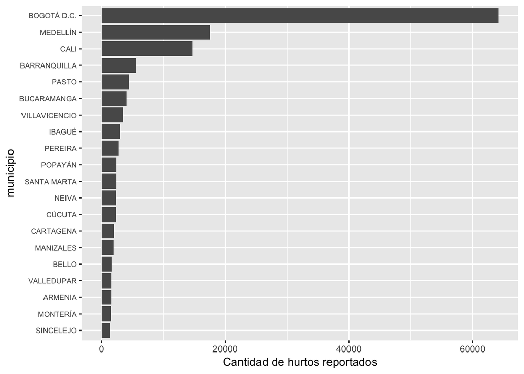

```r
plot_factor(data_hurto_f_l, "municipio", 20)
```

### 4.1.2 Departamentos

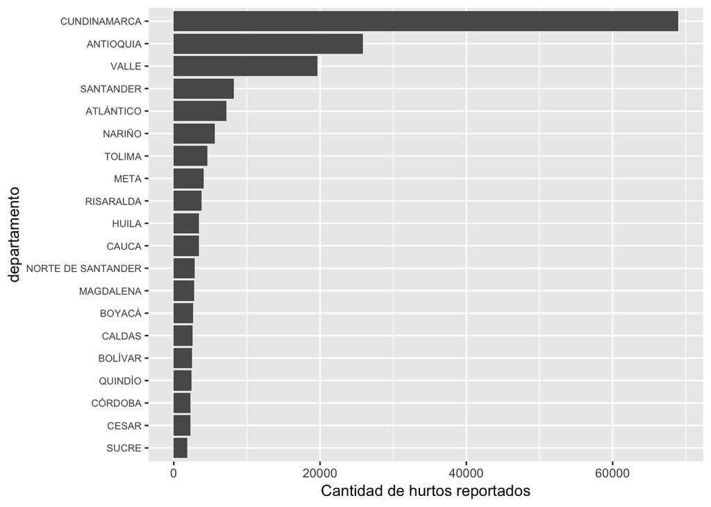

```r
plot_factor(data_hurto_f_l, "departamento", 20)
```

### 4.1.3 Zona

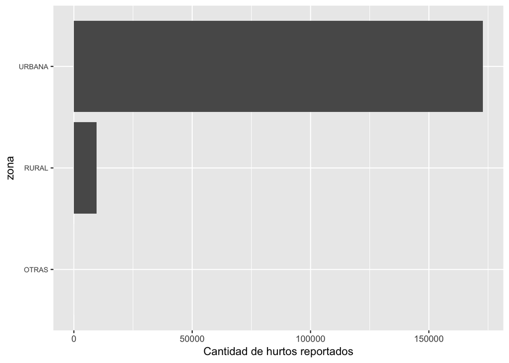

```r
plot_factor(data_hurto_f_l, "zona", 20)
```

### 4.1.4 Clase de sitio

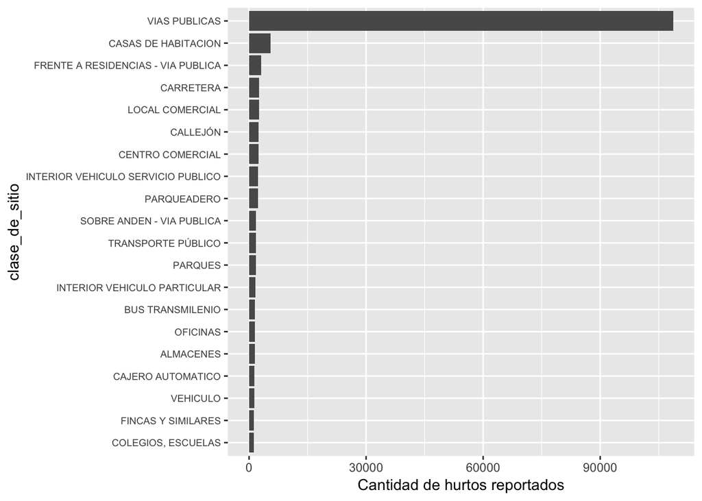

```r
plot_factor(data_hurto_f_l, "clase_de_sitio", 20)
```

```r
#summary(data_hurto_tidy$clase_de_sitio) #esta da un output muy largo
```

### 4.1.5 Arma empleada

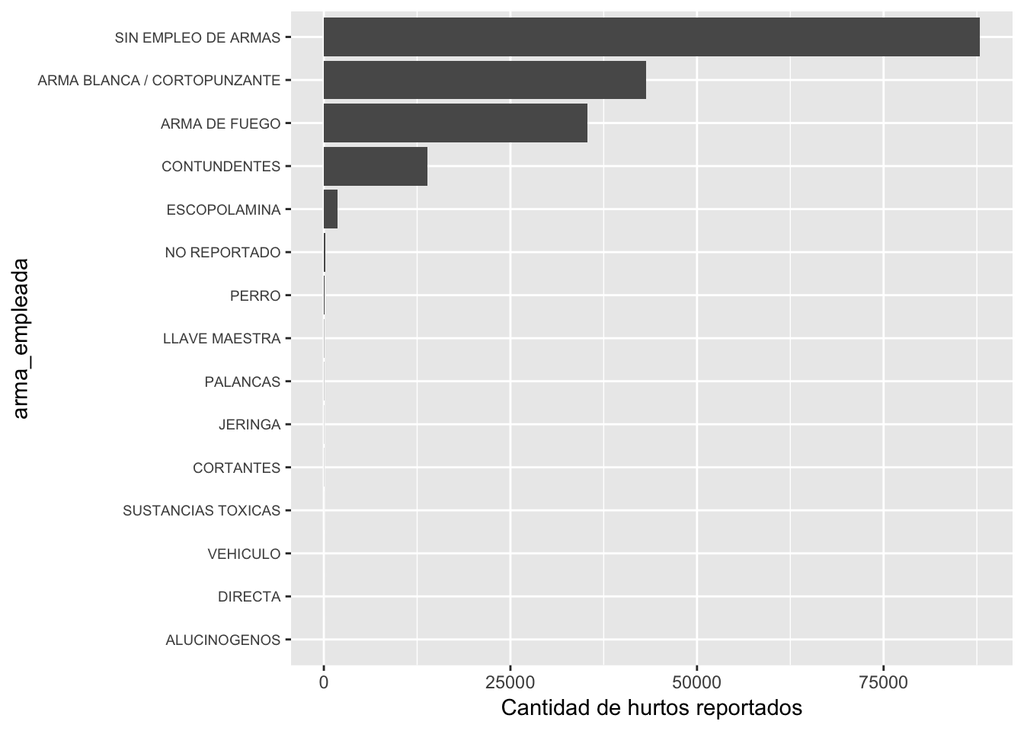

```r
plot_factor(data_hurto_f_l, "arma_empleada", 20)
```

### 4.1.6 Movil Víctima

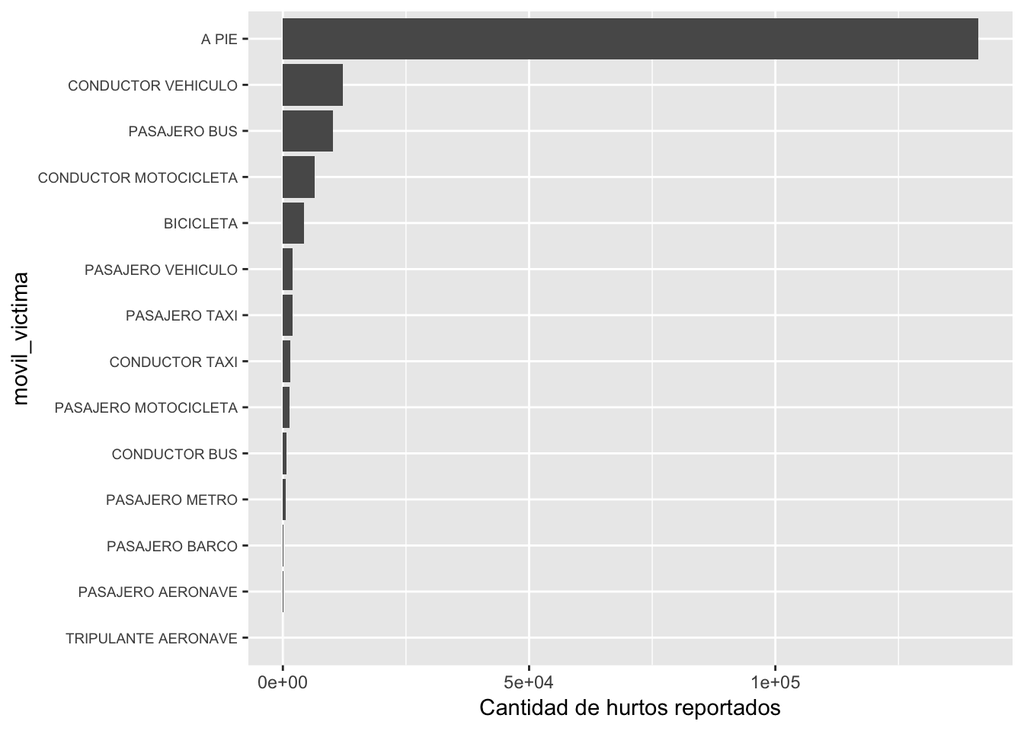

```r
plot_factor(data_hurto_f_l, "movil_victima", 20)
```

### 4.1.7 Sexo

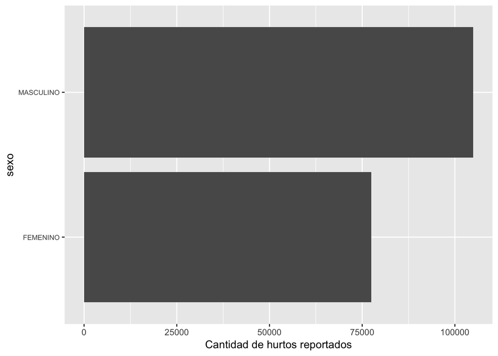

```r
plot_factor(data_hurto_f_l, "sexo", 20)
```

## 4.2 ## Analisis multivariado dataset hurto

Analicemos la relación entre las variables:

```r
arma_spread <- data_hurto %>%
  count(municipio, arma_empleada) %>%
  group_by(municipio) %>%
  mutate(prop = n / sum(n)) %>%
  select(-n) %>%
  spread(key = arma_empleada, value = prop)



arma_spread
```

```
## # A tibble: 897 x 16
## # Groups:   municipio [899]
##    municipio ALUCINOGENOS `ARMA BLANCA / … `ARMA DE FUEGO` CONTUNDENTES
##    <fct>            <dbl>            <dbl>           <dbl>        <dbl>
##  1 ABEJORRAL           NA           0.0625          0.0625       0.125
##  2 ABREGO              NA           0.1             0.3          0.1
##  3 ABRIAQUÍ            NA          NA              NA            0.5
##  4 ACACÍAS             NA           0.116           0.0773       0.159
##  5 ACANDÍ              NA           0.2             0.2         NA
##  6 ACEVEDO             NA           0.182           0.364       NA
##  7 ACHÍ                NA          NA              NA           NA
##  8 AGRADO              NA          NA               0.286       NA
##  9 AGUA DE …           NA           0.0909         NA            0.0909
## 10 AGUACHICA           NA           0.142           0.432        0.0169
## # … with 887 more rows, and 11 more variables: CORTANTES <dbl>,
## #   DIRECTA <dbl>, ESCOPOLAMINA <dbl>, JERINGA <dbl>, `LLAVE
## #   MAESTRA` <dbl>, `NO REPORTADO` <dbl>, PALANCAS <dbl>, PERRO <dbl>,
## #   `SIN EMPLEO DE ARMAS` <dbl>, `SUSTANCIAS TOXICAS` <dbl>,
## #   VEHICULO <dbl>
```

```r
#arma_spread <- munic_spread[order(-munic_spread$cantidad_incauta),]
#munic_spread_sorted

remove_capital_2 <- function(city_factor2) {
  city <- as.character(city_factor2)
  no_capital <- gsub(" \\(CT\\)", "", city)

  return(no_capital)
}

#munic_spread_sorted$municipio <- as.factor(sapply(munic_spread_sorted$municipio, remove_capital_2))
#munic_spread_sorted

#head(arma_spread)

arma_spread <- arma_spread %>%
  left_join(muni_joined_sorted, by = c("municipio" = "municipio"), copy = TRUE)
head(arma_spread)
```

```
## # A tibble: 6 x 19
## # Groups:   municipio [6]
##   municipio ALUCINOGENOS `ARMA BLANCA / … `ARMA DE FUEGO` CONTUNDENTES
##   <chr>            <dbl>            <dbl>           <dbl>        <dbl>
## 1 ABEJORRAL           NA           0.0625          0.0625        0.125
## 2 ABREGO              NA           0.1             0.3           0.1
## 3 ABRIAQUÍ            NA          NA              NA             0.5
## 4 ACACÍAS             NA           0.116           0.0773        0.159
## 5 ACANDÍ              NA           0.2             0.2          NA
## 6 ACEVEDO             NA           0.182           0.364        NA
## # … with 14 more variables: CORTANTES <dbl>, DIRECTA <dbl>,
## #   ESCOPOLAMINA <dbl>, JERINGA <dbl>, `LLAVE MAESTRA` <dbl>, `NO
## #   REPORTADO` <dbl>, PALANCAS <dbl>, PERRO <dbl>, `SIN EMPLEO DE
## #   ARMAS` <dbl>, `SUSTANCIAS TOXICAS` <dbl>, VEHICULO <dbl>,
## #   poblacion_2017 <int>, cantidad_hurtos <int>, indice_hurtos <dbl>
```

```r
arma_spread <- arma_spread[order(-arma_spread$indice_hurtos),]
head(arma_spread)
```

```
## # A tibble: 6 x 19
## # Groups:   municipio [6]
##   municipio ALUCINOGENOS `ARMA BLANCA / … `ARMA DE FUEGO` CONTUNDENTES
##   <chr>            <dbl>            <dbl>           <dbl>        <dbl>
## 1 ARMENIA             NA            0.253           0.125       0.125
## 2 FLORENCIA           NA            0.285           0.162       0.0686
## 3 SAN ANDR…           NA            0.104           0.111       0.0465
## 4 CALDAS              NA            0.121           0.319       0.0638
## 5 SABANALA…           NA            0.138           0.319       0.0426
## 6 RIONEGRO            NA            0.159           0.156       0.142
## # … with 14 more variables: CORTANTES <dbl>, DIRECTA <dbl>,
## #   ESCOPOLAMINA <dbl>, JERINGA <dbl>, `LLAVE MAESTRA` <dbl>, `NO
## #   REPORTADO` <dbl>, PALANCAS <dbl>, PERRO <dbl>, `SIN EMPLEO DE
## #   ARMAS` <dbl>, `SUSTANCIAS TOXICAS` <dbl>, VEHICULO <dbl>,
## #   poblacion_2017 <int>, cantidad_hurtos <int>, indice_hurtos <dbl>
```

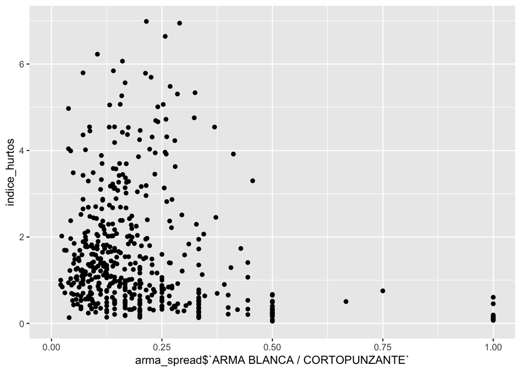

```r
ggplot(arma_spread, aes(x=arma_spread$`ARMA BLANCA / CORTOPUNZANTE`, y=indice_hurtos)) +
  geom_point() +ylim(0, 7) + xlim(0,1)
```

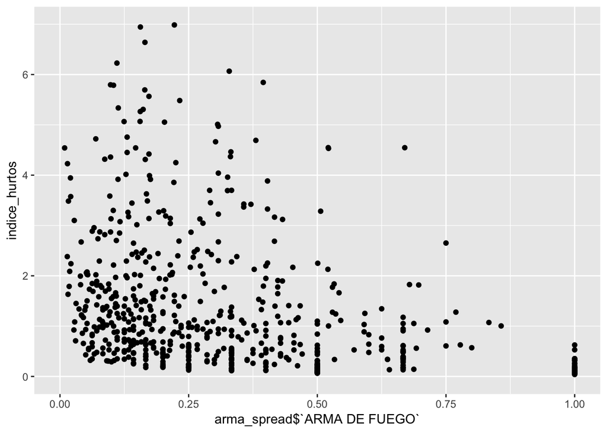

```r
ggplot(arma_spread, aes(x=arma_spread$`ARMA DE FUEGO`, y=indice_hurtos)) +
  geom_point()+ylim(0, 7) + xlim(0,1)
```

# 5 Dataset Incautación armas de fuego 2017

```r
data_incauta_raw <- read.csv("Incautafuego_2017.csv")
str(data_incauta_raw)
```

```
## 'data.frame':    20508 obs. of  10 variables:
##  $ FECHA         : Factor w/ 365 levels "01/01/2017","01/02/2017",..: 1 1 1 1 1 1 1 1 1 1 ...
##  $ DEPARTAMENTO  : Factor w/ 32 levels "AMAZONAS","ANTIOQUIA",..: 1 2 2 2 2 5 5 5 5 5 ...
##  $ MUNICIPIO     : Factor w/ 978 levels "ABEJORRAL","ABREGO",..: 447 38 310 766 827 511 511 511 511 511 ...
##  $ DÍA           : Factor w/ 7 levels "Domingo","Jueves",..: 1 1 1 1 1 1 1 1 1 1 ...
##  $ CLASE.DE.ARMA : Factor w/ 11 levels "AMETRALLADORA",..: 10 10 10 9 3 2 5 7 9 10 ...
##  $ PERMISO       : Factor w/ 2 levels "CON PERMISO",..: 1 2 2 2 1 2 2 2 2 2 ...
##  $ ZONA          : Factor w/ 2 levels "RURAL","URBANA": 1 2 1 1 1 1 1 1 1 1 ...
##  $ CLASE.DE.SITIO: Factor w/ 128 levels "AEROPUERTO","ALCALDIA",..: 127 127 127 50 50 128 128 128 128 128 ...
##  $ CÓDIGO.DANE   : int  91001000 5040000 5282000 5674000 5761000 13458000 13458000 13458000 13458000 13458000 ...
##  $ CANTIDAD      : int  1 1 1 1 1 1 13 1 3 2 ...
```

```r
head(data_incauta_raw)
```

```
##        FECHA DEPARTAMENTO    MUNICIPIO     DÍA CLASE.DE.ARMA     PERMISO
## 1 01/01/2017     AMAZONAS LETICIA (CT) Domingo      REVOLVER CON PERMISO
## 2 01/01/2017    ANTIOQUIA        ANORÍ Domingo      REVOLVER SIN PERMISO
## 3 01/01/2017    ANTIOQUIA     FREDONIA Domingo      REVOLVER SIN PERMISO
## 4 01/01/2017    ANTIOQUIA  SAN VICENTE Domingo       PISTOLA SIN PERMISO
## 5 01/01/2017    ANTIOQUIA     SOPETRÁN Domingo      ESCOPETA CON PERMISO
## 6 01/01/2017      BOLÍVAR  MONTECRISTO Domingo      CARABINA SIN PERMISO
##     ZONA     CLASE.DE.SITIO CÓDIGO.DANE CANTIDAD
## 1  RURAL      VIAS PUBLICAS    91001000        1
## 2 URBANA      VIAS PUBLICAS     5040000        1
## 3  RURAL      VIAS PUBLICAS     5282000        1
## 4  RURAL FINCAS Y SIMILARES     5674000        1
## 5  RURAL FINCAS Y SIMILARES     5761000        1
## 6  RURAL     ZONA SELVÁTICA    13458000        1
```

## 5.1 Limpieza Dataset sobre armas incautadas en 2017

```r
removable_columns_2 <- c("FECHA", "HORA", "PERMISO", "CÓDIGO.DANE", "CANTIDAD")

data_incauta_tidy <- data_incauta_raw[,-which(colnames(data_incauta_raw) %in% removable_columns_2)]

str(data_incauta_tidy)
```

```
## 'data.frame':    20508 obs. of  6 variables:
##  $ DEPARTAMENTO  : Factor w/ 32 levels "AMAZONAS","ANTIOQUIA",..: 1 2 2 2 2 5 5 5 5 5 ...
##  $ MUNICIPIO     : Factor w/ 978 levels "ABEJORRAL","ABREGO",..: 447 38 310 766 827 511 511 511 511 511 ...
##  $ DÍA           : Factor w/ 7 levels "Domingo","Jueves",..: 1 1 1 1 1 1 1 1 1 1 ...
##  $ CLASE.DE.ARMA : Factor w/ 11 levels "AMETRALLADORA",..: 10 10 10 9 3 2 5 7 9 10 ...
##  $ ZONA          : Factor w/ 2 levels "RURAL","URBANA": 1 2 1 1 1 1 1 1 1 1 ...
##  $ CLASE.DE.SITIO: Factor w/ 128 levels "AEROPUERTO","ALCALDIA",..: 127 127 127 50 50 128 128 128 128 128 ...
```

Normalizamos los nombres de las columnas.

```r
colnames(data_incauta_tidy) <- c("departamento", "municipio", "dia","clase_de_arma", "zona", "clase_de_sitio")
str(data_incauta_tidy)
```

```
## 'data.frame':    20508 obs. of  6 variables:
##  $ departamento  : Factor w/ 32 levels "AMAZONAS","ANTIOQUIA",..: 1 2 2 2 2 5 5 5 5 5 ...
##  $ municipio     : Factor w/ 978 levels "ABEJORRAL","ABREGO",..: 447 38 310 766 827 511 511 511 511 511 ...
##  $ dia           : Factor w/ 7 levels "Domingo","Jueves",..: 1 1 1 1 1 1 1 1 1 1 ...
##  $ clase_de_arma : Factor w/ 11 levels "AMETRALLADORA",..: 10 10 10 9 3 2 5 7 9 10 ...
##  $ zona          : Factor w/ 2 levels "RURAL","URBANA": 1 2 1 1 1 1 1 1 1 1 ...
##  $ clase_de_sitio: Factor w/ 128 levels "AEROPUERTO","ALCALDIA",..: 127 127 127 50 50 128 128 128 128 128 ...
```

## 5.2 Analisis univariado dataset Armas

Aquí se tiene el analisis univariado para las siguientes variables: *Departamento* Municipio *Día* Clase de arma *Zona* Clase de sitio

A continuación empezamos a analizar cada una de las variables listadas. Vamos a observar como esta la distribución de estos datos

```r
data_armas<-data_incauta_tidy
columns_f_l_armas <- c("departamento", "municipio", "dia","clase_de_arma", "zona", "clase_de_sitio")
data_hurto_f_l_armas <- data_armas[, colnames(data_armas) %in% columns_f_l_armas]
summary(data_hurto_f_l_armas)
```

```
##              departamento              municipio            dia
##  CUNDINAMARCA      :3218   BOGOTÁ D.C. (CT) : 1829   Domingo  :3172
##  VALLE             :1999   BARRANQUILLA (CT): 1066   Jueves   :3061
##  ANTIOQUIA         :1958   CALI (CT)        : 1061   Lunes    :2876
##  ATLÁNTICO         :1648   MEDELLÍN (CT)    :  563   Martes   :2736
##  SANTANDER         :1488   CÚCUTA (CT)      :  403   Miércoles:2802
##  NORTE DE SANTANDER:1003   CARTAGENA (CT)   :  375   Sábado   :2840
##  (Other)           :9194   (Other)          :15211   Viernes  :3021
##            clase_de_arma      zona
##  REVOLVER         :8695   RURAL : 6150
##  ESCOPETA         :5503   URBANA:14358
##  PISTOLA          :4573
##  ESCOPETA DE FISTO:1440
##  FUSIL / RIFLE    : 154
##  SUBAMETRALLADORA :  82
##  (Other)          :  61
##                      clase_de_sitio
##  VIAS PUBLICAS              :14030
##  FINCAS Y SIMILARES         : 1408
##  CARRETERA                  : 1301
##  CASAS DE HABITACION        : 1014
##  TRAMO DE VIA               :  672
##  INSTALACIONES DE LA POLICIA:  411
##  (Other)                    : 1672
```

```r
plot_factor <- function(data, column, top = 30) {
  group_count <- data %>%
    group_by_(column) %>%
    summarise(
      cantidad_armas = n()
    ) %>%
    arrange(desc(cantidad_armas)) %>%
    top_n(top)
  ggplot(group_count) +
    geom_bar(
      aes_string(x = paste0("reorder(", column, ", cantidad_armas)"), y = "cantidad_armas"),
      stat = "identity"
    ) +
    coord_flip() +
    labs(x = column, y = "Cantidad reportada de armas incautadas") +
    theme(axis.text.y = element_text(size = (rel(0.8))))
}
```

### 5.2.1 Departamentos

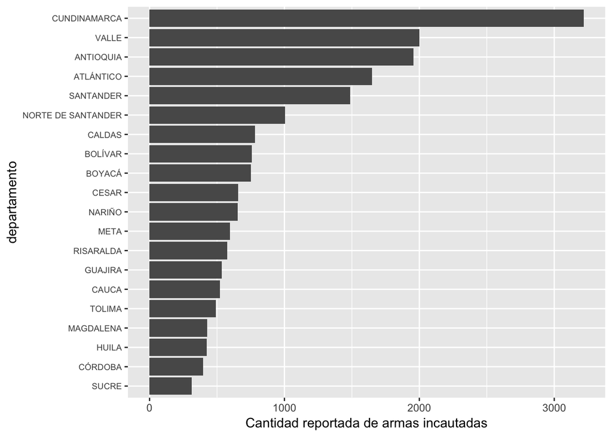

```r
plot_factor(data_hurto_f_l_armas, "departamento", 20)
```

### 5.2.2 Municipio

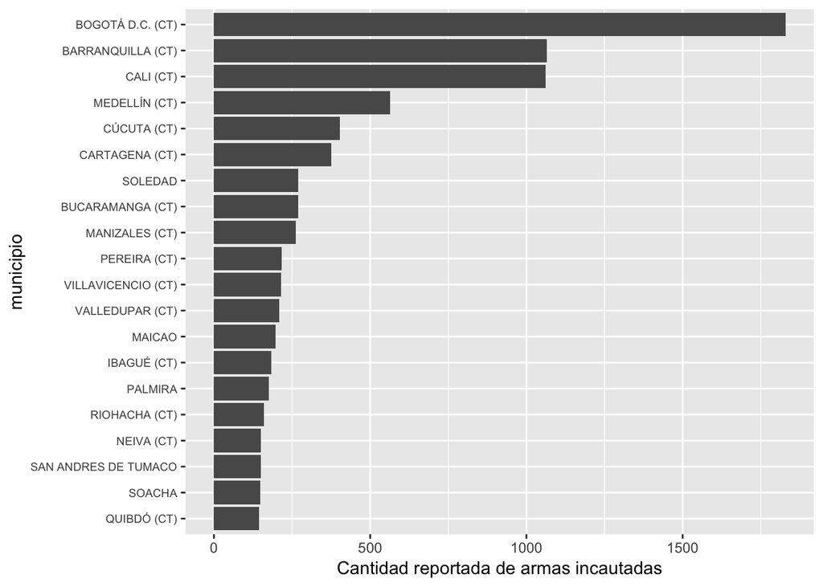

```r
plot_factor(data_hurto_f_l_armas, "municipio", 20)
```

### 5.2.3 Día

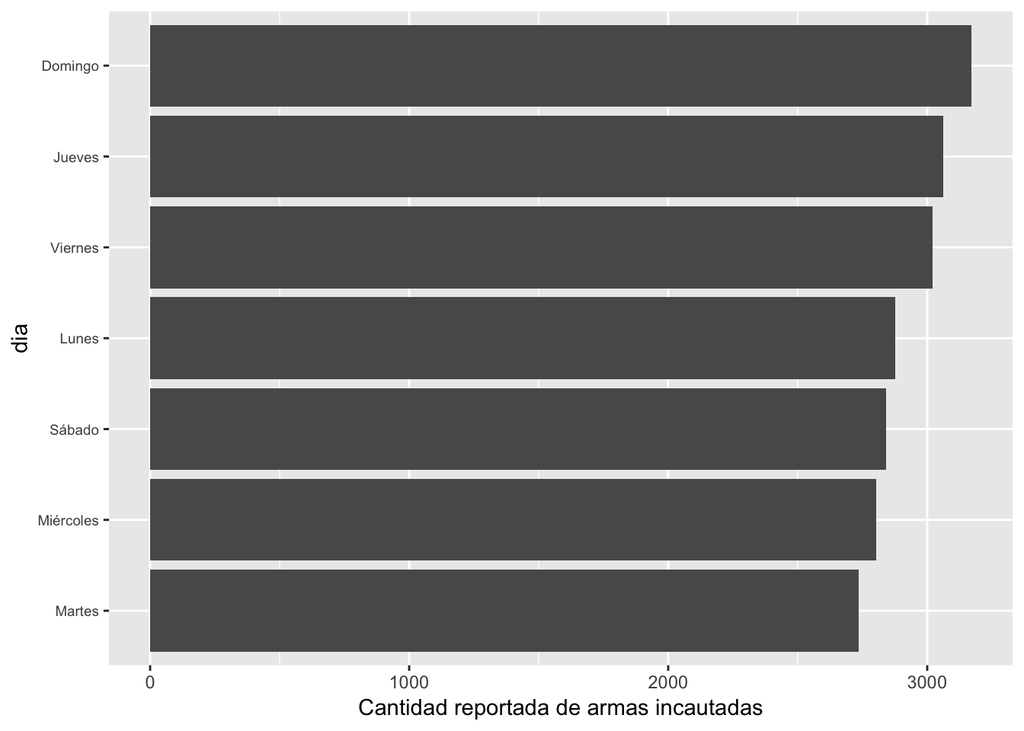

```r
plot_factor(data_hurto_f_l_armas, "dia", 20)
```

### 5.2.4 Clase de arma empleada

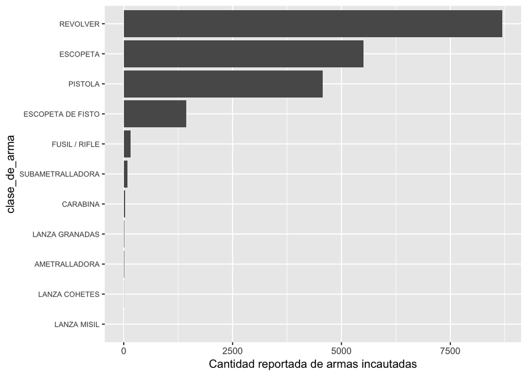

```r
plot_factor(data_hurto_f_l_armas, "clase_de_arma", 20)
```

### 5.2.5 Zona

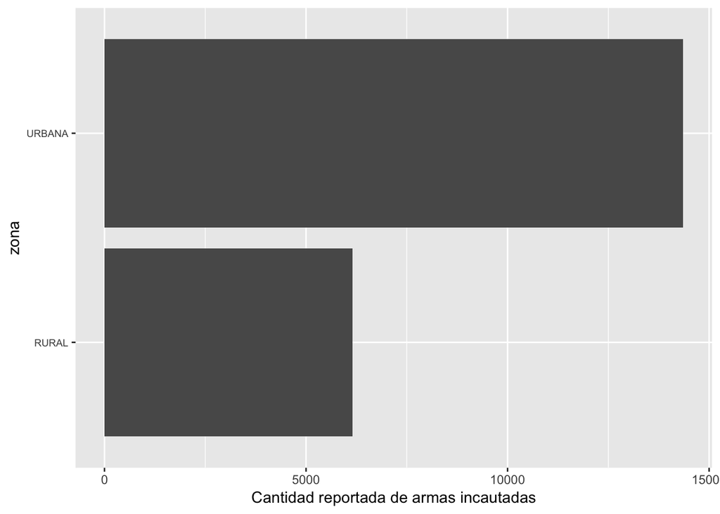

```r
plot_factor(data_hurto_f_l_armas, "zona", 20)
```

### 5.2.6 Clase de sitio

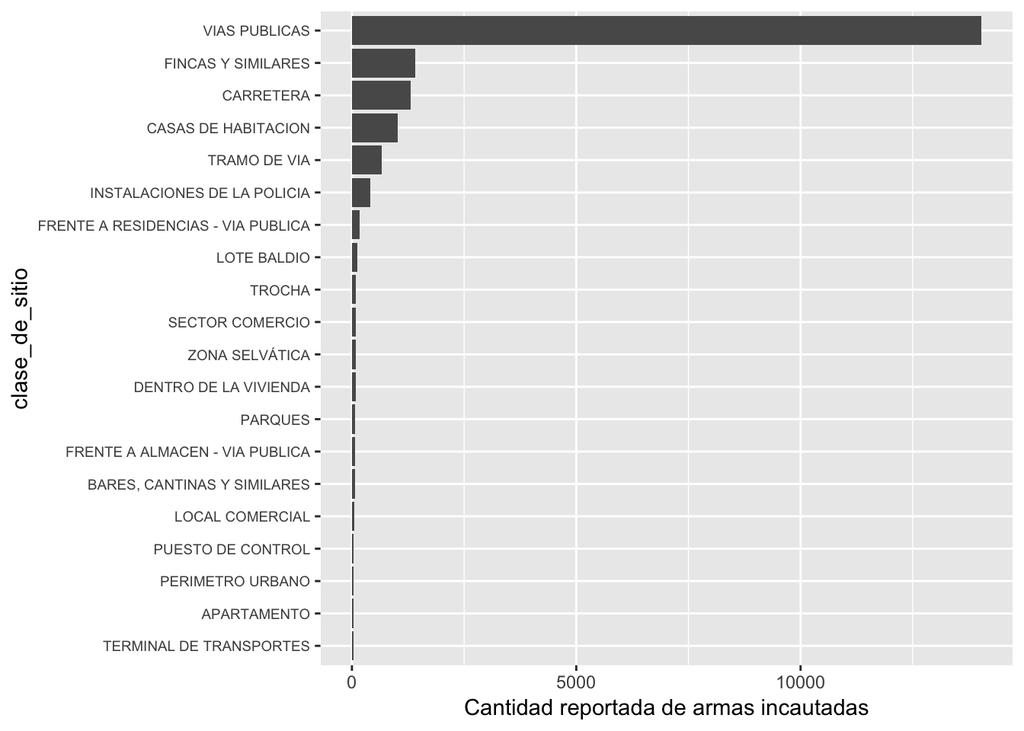

```r
plot_factor(data_hurto_f_l_armas, "clase_de_sitio", 20)
```

## 5.3 ##Analisis multivariado dataset armas incautadas

El dataset de armas incautadas fue seleccionado pues, se cuenta con la hipotesis de a mayor cantidad de armas incautadas, menor serà el indice de hurtos. De manera que se pasa a realizar un analisis multivariado con dicha variable. A continuaciòn los resultados:

```r
head(data_hurto_f_l_armas)
```

```
##   departamento    municipio     dia clase_de_arma   zona
## 1     AMAZONAS LETICIA (CT) Domingo      REVOLVER  RURAL
## 2    ANTIOQUIA        ANORÍ Domingo      REVOLVER URBANA
## 3    ANTIOQUIA     FREDONIA Domingo      REVOLVER  RURAL
## 4    ANTIOQUIA  SAN VICENTE Domingo       PISTOLA  RURAL
## 5    ANTIOQUIA     SOPETRÁN Domingo      ESCOPETA  RURAL
## 6      BOLÍVAR  MONTECRISTO Domingo      CARABINA  RURAL
##       clase_de_sitio
## 1      VIAS PUBLICAS
## 2      VIAS PUBLICAS
## 3      VIAS PUBLICAS
## 4 FINCAS Y SIMILARES
## 5 FINCAS Y SIMILARES
## 6     ZONA SELVÁTICA
```

```r
munic_spread <- data_hurto_f_l_armas %>%
  group_by(municipio) %>%
  summarize(
    cantidad_incauta = n()
  )

munic_spread
```

```
## # A tibble: 978 x 2
##    municipio    cantidad_incauta
##    <fct>                   <int>
##  1 ABEJORRAL                  16
##  2 ABREGO                     24
##  3 ABRIAQUÍ                    1
##  4 ACACÍAS                    35
##  5 ACANDÍ                      6
##  6 ACEVEDO                     2
##  7 ACHÍ                        2
##  8 AGRADO                      4
##  9 AGUA DE DIOS                2
## 10 AGUACHICA                  70
## # … with 968 more rows
```

```r
munic_spread_sorted <- munic_spread[order(-munic_spread$cantidad_incauta),]
munic_spread_sorted
```

```
## # A tibble: 978 x 2
##    municipio         cantidad_incauta
##    <fct>                        <int>
##  1 BOGOTÁ D.C. (CT)              1829
##  2 BARRANQUILLA (CT)             1066
##  3 CALI (CT)                     1061
##  4 MEDELLÍN (CT)                  563
##  5 CÚCUTA (CT)                    403
##  6 CARTAGENA (CT)                 375
##  7 BUCARAMANGA (CT)               269
##  8 SOLEDAD                        269
##  9 MANIZALES (CT)                 261
## 10 PEREIRA (CT)                   217
## # … with 968 more rows
```

```r
remove_capital_2 <- function(city_factor2) {
  city <- as.character(city_factor2)
  no_capital <- gsub(" \\(CT\\)", "", city)

  return(no_capital)
}

munic_spread_sorted$municipio <- as.factor(sapply(munic_spread_sorted$municipio, remove_capital_2))
munic_spread_sorted
```

```
## # A tibble: 978 x 2
##    municipio    cantidad_incauta
##    <fct>                   <int>
##  1 BOGOTÁ D.C.              1829
##  2 BARRANQUILLA             1066
##  3 CALI                     1061
##  4 MEDELLÍN                  563
##  5 CÚCUTA                    403
##  6 CARTAGENA                 375
##  7 BUCARAMANGA               269
##  8 SOLEDAD                   269
##  9 MANIZALES                 261
## 10 PEREIRA                   217
## # … with 968 more rows
```

```r
head(munic_spread_sorted)
```

```
## # A tibble: 6 x 2
##   municipio    cantidad_incauta
##   <fct>                   <int>
## 1 BOGOTÁ D.C.              1829
## 2 BARRANQUILLA             1066
## 3 CALI                     1061
## 4 MEDELLÍN                  563
## 5 CÚCUTA                    403
## 6 CARTAGENA                 375
```

```r
head(muni_joined_sorted)
```

```
##         municipio poblacion_2017 cantidad_hurtos indice_hurtos
## 149   BOGOTÁ D.C.        8080734           64188      7.943338
## 1        MEDELLÍN        2508452           17522      6.985184
## 1006         CALI        2420114           14681      6.066243
## 126  BARRANQUILLA        1228271            5585      4.547042
## 150     CARTAGENA        1024882            1954      1.906561
## 780        CÚCUTA         662673            2267      3.420993
```

```r
munic_spread_sorted <- munic_spread_sorted %>%
  left_join(muni_joined_sorted, by = c("municipio" = "municipio"), copy = TRUE)

head(munic_spread_sorted)
```

```
## # A tibble: 6 x 5
##   municipio   cantidad_incauta poblacion_2017 cantidad_hurtos indice_hurtos
##   <chr>                  <int>          <int>           <int>         <dbl>
## 1 BOGOTÁ D.C.             1829        8080734           64188          7.94
## 2 BARRANQUIL…             1066        1228271            5585          4.55
## 3 CALI                    1061        2420114           14681          6.07
## 4 MEDELLÍN                 563        2508452           17522          6.99
## 5 CÚCUTA                   403         662673            2267          3.42
## 6 CARTAGENA                375        1024882            1954          1.91
```

```r
munic_spread_sorted <- munic_spread_sorted[order(-munic_spread_sorted$cantidad_incauta),]

str(munic_spread_sorted)
```

```
## Classes 'tbl_df', 'tbl' and 'data.frame':    1063 obs. of  5 variables:
##  $ municipio       : chr  "BOGOTÁ D.C." "BARRANQUILLA" "CALI" "MEDELLÍN" ...
##  $ cantidad_incauta: int  1829 1066 1061 563 403 375 269 269 261 217 ...
##  $ poblacion_2017  : int  8080734 1228271 2420114 2508452 662673 1024882 528497 649111 398830 474335 ...
##  $ cantidad_hurtos : int  64188 5585 14681 17522 2267 1954 4068 1079 1883 2701 ...
##  $ indice_hurtos   : num  7.94 4.55 6.07 6.99 3.42 ...
```

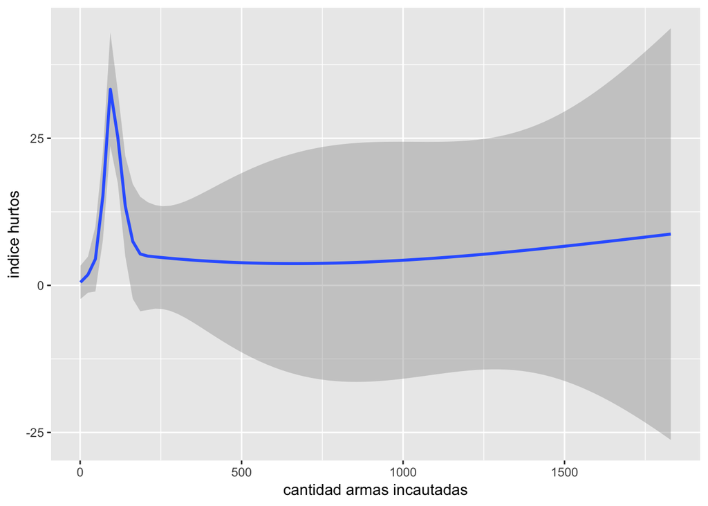

```r
ggplot(munic_spread_sorted) +
  stat_smooth(mapping = aes(x=munic_spread_sorted$cantidad_incauta, y=munic_spread_sorted$indice_hurtos)) +
  xlab("cantidad armas incautadas") +
  ylab("indice hurtos")
```

```r
munic_spread_sorted<-head(munic_spread_sorted,30)
#munic_spread_sorted$indice_hurtos<-as.integer(munic_spread_sorted$indice_hurtos)
munic_spread_sorted
```

```
## # A tibble: 30 x 5
##    municipio  cantidad_incauta poblacion_2017 cantidad_hurtos indice_hurtos
##    <chr>                 <int>          <int>           <int>         <dbl>
##  1 BOGOTÁ D.…             1829        8080734           64188          7.94
##  2 BARRANQUI…             1066        1228271            5585          4.55
##  3 CALI                   1061        2420114           14681          6.07
##  4 MEDELLÍN                563        2508452           17522          6.99
##  5 CÚCUTA                  403         662673            2267          3.42
##  6 CARTAGENA               375        1024882            1954          1.91
##  7 BUCARAMAN…              269         528497            4068          7.70
##  8 SOLEDAD                 269         649111            1079          1.66
##  9 MANIZALES               261         398830            1883          4.72
## 10 PEREIRA                 217         474335            2701          5.69
## # … with 20 more rows
```

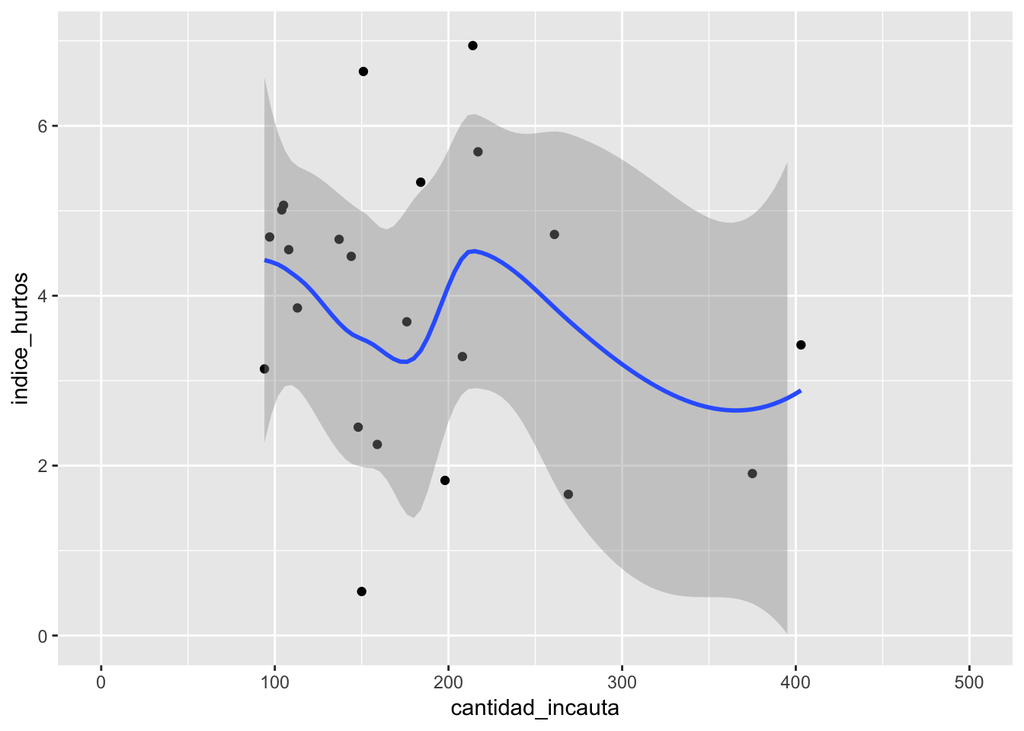

```r
#d <- ggplot(munic_spread_sorted, aes(x = indice_hurtos, y = cantidad_incauta))
#d + geom_line(stat = "identity")

ggplot(munic_spread_sorted, aes(x=cantidad_incauta, y=indice_hurtos)) +
  geom_point()+geom_smooth() +ylim(0, 7) + xlim(0,500)
```